# Analysis of The Programme for International Student Assessment (PISA) Program [application on 2012 dataset]

## data description and project overview

### What is the Pisa Programme?

"The Programme for International Student Assessment (PISA) is an international survey which aims to evaluate education systems worldwide by testing the skills and knowledge of 15-year-old students who are nearing the end of their compulsory education in the key subjects: reading, mathematics and science.This survey gives us insights into how the students' background and school environment could influence their performance."

Source: [Pisa Programme Description](http://www.oecd.org/pisa/aboutpisa/)

### Pisa 2012

"PISA 2012 is the programme’s 5th survey.

- It assessed the competencies of 15-year-olds in reading, mathematics and science.
- covered 65 countries and economies.
- surveyed 510 000 students.
- age group [15 years and 3 months : 16 years 2 months]

Source: [Pisa 2012 Survey Description](http://www.oecd.org/pisa/aboutpisa/pisa-2012-results.htm)

### Regional devision

to map the country by region, we could analyze the regional impact of the quality of education. I used the reference of the world bank classification

## Import libraries

```python
# import libraries
import pandas as pd
import matplotlib.pyplot as plt
from scipy.stats import pearsonr
%matplotlib inline
import numpy as np
import seaborn as sns
```

```python
# due to the large number of columns [>600], we made a limit of 700 columns in order to capture all of them
pd.set_option('display.max_rows', 700)
pd.set_option('display.max_columns', 700)
```

## read the Data

to follow along, you need to download your own version of the data to work on it from those links

1. https://s3.amazonaws.com/udacity-hosted-downloads/ud507/pisa2012.csv.zip
2. https://s3.amazonaws.com/udacity-hosted-downloads/ud507/pisadict2012.csv

```python
# let's import the dataset
pisa_2012 = pd.read_csv(r"C:\Users\nahla\Downloads\Nanodegree Deadline\pisa data\pisa2012.csv",encoding='latin-1', low_memory = False)
```

```python
#import the column descriptions accordingly
pisa_2012_dict = pd.read_csv(r"C:\Users\nahla\Downloads\Nanodegree Deadline\pisa data\pisadict2012.csv",
                        encoding='latin-1', low_memory = False)
```

```python
# import the external world bank data, regarding countries classification

country_list=pd.read_excel(r"C:\Users\nahla\Downloads\Nanodegree Deadline\pisa data\country group listing.xlsx")
```

## Data Investigation

overview on the sample data

```python
pisa_2012.sample(3)
```

|  | Unnamed: 0 | CNT | SUBNATIO | STRATUM | OECD | NC | SCHOOLID | STIDSTD | ST01Q01 | ST02Q01 | ST03Q01 | ST03Q02 | ST04Q01 | ST05Q01 | ST06Q01 | ST07Q01 | ST07Q02 | ST07Q03 | ST08Q01 | ST09Q01 | ST115Q01 | ST11Q01 | ST11Q02 | ST11Q03 | ST11Q04 | ST11Q05 | ST11Q06 | ST13Q01 | ST14Q01 | … |
| --- | --- | --- | --- | --- | --- | --- | --- | --- | --- | --- | --- | --- | --- | --- | --- | --- | --- | --- | --- | --- | --- | --- | --- | --- | --- | --- | --- | --- | --- | --- |
| 80296 | 80297 | Canada | 1240000 | CAN0437 | OECD | Canada | 235 | 5827 | 10 | 2.0 | 10 | 1996 | Female | Yes, for more than one year | 5.0 | No, never | No, never | No, never | None | None | 1.0 | Yes | Yes | NaN | NaN | NaN | NaN | <ISCED level 3A> | No | … |
| 226868 | 226869 | Indonesia | 3600000 | IDN0001 | Non-OECD | Indonesia | 205 | 5480 | 10 | 3.0 | 10 | 1996 | Male | No | 5.0 | No, never | No, never | NaN | None | None | 1.0 | Yes | No | No | Yes | Yes | Yes | <ISCED level 3A> | No | … |
| 150399 | 150400 | Spain | 7240600 | ESP0612 | OECD | Spain | 170 | 4817 | 10 | 1.0 | 1 | 1996 | Male | Yes, for more than one year | 5.0 | No, never | No, never | NaN | One or two times | One or two times | 3.0 | Yes | Yes | No | Yes | No | No | <ISCED level 3A> | NaN | … |

check the table columns

```python
pisa_2012.columns
```

```
Index(['Unnamed: 0', 'CNT', 'SUBNATIO', 'STRATUM', 'OECD', 'NC', 'SCHOOLID',
       'STIDSTD', 'ST01Q01', 'ST02Q01',
       ...
       'W_FSTR75', 'W_FSTR76', 'W_FSTR77', 'W_FSTR78', 'W_FSTR79', 'W_FSTR80',
       'WVARSTRR', 'VAR_UNIT', 'SENWGT_STU', 'VER_STU'],
      dtype='object', length=636)
```

So we have results for:

- 485.490 children.
- age [between 15 years 3 months and 16 years 2 months]
- the children are from multiple countries
- there are 636 columns
- dataset is greater than 2.5 GB
- the number of participants vary across different countries

investigating dict file

```python
pisa_2012_dict
```

|  | Unnamed: 0 | x |
| --- | --- | --- |
| 0 | CNT | Country code 3-character |
| 1 | SUBNATIO | Adjudicated sub-region code 7-digit code (3-di... |
| 2 | STRATUM | Stratum ID 7-character (cnt + region ID + orig... |
| 3 | OECD | OECD country |
| 4 | NC | National Centre 6-digit Code |
| 5 | SCHOOLID | School ID 7-digit (region ID + stratum ID + 3-... |
| 6 | STIDSTD | Student ID |
| 7 | ST01Q01 | International Grade |
| 8 | ST02Q01 | National Study Programme |
| 9 | ST03Q01 | Birth - Month |
| 10 | ST03Q02 | Birth -Year |
| 11 | ST04Q01 | Gender |
| 12 | ST05Q01 | Attend <ISCED 0> |
| 13 | ST06Q01 | Age at <ISCED 1> |
| 14 | ST07Q01 | Repeat - <ISCED 1> |
| 15 | ST07Q02 | Repeat - <ISCED 2> |
| 16 | ST07Q03 | Repeat - <ISCED 3> |
| 17 | ST08Q01 | Truancy - Late for School |
| 18 | ST09Q01 | Truancy - Skip whole school day |
| 19 | ST115Q01 | Truancy - Skip classes within school day |
| 20 | ST11Q01 | At Home - Mother |
| 21 | ST11Q02 | At Home - Father |
| 22 | ST11Q03 | At Home - Brothers |
| 23 | ST11Q04 | At Home - Sisters |
| 24 | ST11Q05 | At Home - Grandparents |
| 25 | ST11Q06 | At Home - Others |
| 26 | ST13Q01 | Mother<Highest Schooling> |
| 27 | ST14Q01 | Mother Qualifications - <ISCED level 6> |
| 28 | ST14Q02 | Mother Qualifications - <ISCED level 5A> |
| 29 | ST14Q03 | Mother Qualifications - <ISCED level 5B> |

[output cut: 605 more lines]

dictionary file is vital to understand the data and start wranging it

### Key Questions

- performance of the students on different subjects (Math, Reading and Science)?
- calculate the score for each subject and student[based on the mean value of the computed values (1 to 5)]
- Does country has an impact on the students performance?
- Does Gender has an impact on the results?
- Does the internet performance has an impacat on the students results?

## Data Wrangling

in this step we clean the data

```python
# limit the dataset to the columns we actually need to answer our questions
pisa_2012_clean = pisa_2012[['CNT', 'ST03Q02', 'ST04Q01', 'AGE', 'PV1MATH', 'PV2MATH',
                       'PV3MATH', 'PV4MATH', 'PV5MATH', 'PV1READ', 'PV2READ',
         'PV3READ', 'PV4READ', 'PV5READ','PV1SCIE', 'PV2SCIE', 'PV3SCIE', 'PV4SCIE',
                       'PV5SCIE', 'ST26Q06'  ]]
```

```python
pisa_2012_clean
```

|  | CNT | ST03Q02 | ST04Q01 | AGE | PV1MATH | PV2MATH | PV3MATH | PV4MATH | PV5MATH | PV1READ | PV2READ | PV3READ | PV4READ | PV5READ | PV1SCIE | PV2SCIE | PV3SCIE | PV4SCIE | PV5SCIE | ST26Q06 |
| --- | --- | --- | --- | --- | --- | --- | --- | --- | --- | --- | --- | --- | --- | --- | --- | --- | --- | --- | --- | --- |
| 0 | Albania | 1996 | Female | 16.17 | 406.8469 | 376.4683 | 344.5319 | 321.1637 | 381.9209 | 249.5762 | 254.3420 | 406.8496 | 175.7053 | 218.5981 | 341.7009 | 408.8400 | 348.2283 | 367.8105 | 392.9877 | No |
| 1 | Albania | 1996 | Female | 16.17 | 486.1427 | 464.3325 | 453.4273 | 472.9008 | 476.0165 | 406.2936 | 349.8975 | 400.7334 | 369.7553 | 396.7618 | 548.9929 | 471.5964 | 471.5964 | 443.6218 | 454.8116 | Yes |
| 2 | Albania | 1996 | Female | 15.58 | 533.2684 | 481.0796 | 489.6479 | 490.4269 | 533.2684 | 401.2100 | 404.3872 | 387.7067 | 431.3938 | 401.2100 | 499.6643 | 428.7952 | 492.2044 | 512.7191 | 499.6643 | Yes |
| 3 | Albania | 1996 | Female | 15.67 | 412.2215 | 498.6836 | 415.3373 | 466.7472 | 454.2842 | 547.3630 | 481.4353 | 461.5776 | 425.0393 | 471.9036 | 438.6796 | 481.5740 | 448.9370 | 474.1141 | 426.5573 | Yes |
| 4 | Albania | 1996 | Female | 15.50 | 381.9209 | 328.1742 | 403.7311 | 418.5309 | 395.1628 | 311.7707 | 141.7883 | 293.5015 | 272.8495 | 260.1405 | 361.5628 | 275.7740 | 372.7527 | 403.5248 | 422.1746 | Yes |
| ... | ... | ... | ... | ... | ... | ... | ... | ... | ... | ... | ... | ... | ... | ... | ... | ... | ... | ... | ... | ... |
| 485485 | Vietnam | 1996 | Female | 15.83 | 477.1849 | 493.5426 | 479.5217 | 486.5322 | 494.3215 | 460.2272 | 476.1134 | 472.9362 | 472.1419 | 481.6736 | 559.8098 | 528.1052 | 519.7128 | 535.5651 | 538.3626 | No |
| 485486 | Vietnam | 1996 | Male | 16.17 | 518.9360 | 515.8202 | 505.6940 | 596.8297 | 508.8098 | 490.9325 | 479.7053 | 448.4294 | 565.5134 | 451.6372 | 538.7355 | 493.9761 | 493.0436 | 561.1153 | 535.0056 | Yes |
| 485487 | Vietnam | 1996 | Male | 15.83 | 475.2376 | 482.2480 | 507.9530 | 457.3220 | 508.7319 | 462.6239 | 514.7503 | 434.5558 | 457.8122 | 511.5425 | 536.8706 | 571.3726 | 488.3812 | 548.9929 | 563.9127 | No |
| 485488 | Vietnam | 1996 | Male | 15.83 | 550.9503 | 517.4560 | 529.1401 | 515.8981 | 501.0983 | 505.2873 | 522.1282 | 513.3068 | 528.5437 | 522.9301 | 511.0407 | 532.4879 | 524.0955 | 551.1376 | 514.7706 | Yes |
| 485489 | Vietnam | 1996 | Female | 15.33 | 470.0187 | 441.1980 | 475.4713 | 441.9769 | 443.5348 | 532.3506 | 483.1034 | 479.9261 | 459.2741 | 488.6635 | 530.6229 | 473.7411 | 477.4711 | 477.4711 | 505.4457 | NaN |

485490 rows × 20 columns

```python
#get the info about the new clean data
pisa_2012_clean.info()
```

```
<class 'pandas.core.frame.DataFrame'>
RangeIndex: 485490 entries, 0 to 485489
Data columns (total 20 columns):
 #   Column   Non-Null Count   Dtype
---  ------   --------------   -----
 0   CNT      485490 non-null  object
 1   ST03Q02  485490 non-null  int64
 2   ST04Q01  485490 non-null  object
 3   AGE      485374 non-null  float64
 4   PV1MATH  485490 non-null  float64
 5   PV2MATH  485490 non-null  float64
 6   PV3MATH  485490 non-null  float64
 7   PV4MATH  485490 non-null  float64
 8   PV5MATH  485490 non-null  float64
 9   PV1READ  485490 non-null  float64
 10  PV2READ  485490 non-null  float64
 11  PV3READ  485490 non-null  float64
 12  PV4READ  485490 non-null  float64
 13  PV5READ  485490 non-null  float64
 14  PV1SCIE  485490 non-null  float64
 15  PV2SCIE  485490 non-null  float64
 16  PV3SCIE  485490 non-null  float64
 17  PV4SCIE  485490 non-null  float64
 18  PV5SCIE  485490 non-null  float64
 19  ST26Q06  473182 non-null  object
dtypes: float64(16), int64(1), object(3)
memory usage: 74.1+ MB
```

Now, in order to clean the data we want to replace the NaN values for the age of a student by the mean age in the whole data base

```python
# replace missing age values with the mean age in the dataset
pisa_2012_clean.loc[np.isfinite(pisa_2012_clean['AGE']) == False, 'AGE'] = pisa_2012_clean['AGE'].mean()
```

```python
# next cleaning step of NaN values in the ST26Q06 (Internet Access) column
pisa_2012_clean['ST26Q06'].value_counts()
```

```
Yes    402040
No      71142
Name: ST26Q06, dtype: int64
```

We replace the NaN values with the string 'Unknown'.

```python
pisa_2012_clean.loc[pisa_2012_clean['ST26Q06'].isna() == True,'ST26Q06'] = 'Unknown'
```

```python
pisa_2012_clean.info()
```

```
<class 'pandas.core.frame.DataFrame'>
RangeIndex: 485490 entries, 0 to 485489
Data columns (total 20 columns):
 #   Column   Non-Null Count   Dtype
---  ------   --------------   -----
 0   CNT      485490 non-null  object
 1   ST03Q02  485490 non-null  int64
 2   ST04Q01  485490 non-null  object
 3   AGE      485490 non-null  float64
 4   PV1MATH  485490 non-null  float64
 5   PV2MATH  485490 non-null  float64
 6   PV3MATH  485490 non-null  float64
 7   PV4MATH  485490 non-null  float64
 8   PV5MATH  485490 non-null  float64
 9   PV1READ  485490 non-null  float64
 10  PV2READ  485490 non-null  float64
 11  PV3READ  485490 non-null  float64
 12  PV4READ  485490 non-null  float64
 13  PV5READ  485490 non-null  float64
 14  PV1SCIE  485490 non-null  float64
 15  PV2SCIE  485490 non-null  float64
 16  PV3SCIE  485490 non-null  float64
 17  PV4SCIE  485490 non-null  float64
 18  PV5SCIE  485490 non-null  float64
 19  ST26Q06  485490 non-null  object
dtypes: float64(16), int64(1), object(3)
memory usage: 74.1+ MB
```

after cleaning the data, there is now no NAN values, its now ready for visualization and further analysis

second step would be summing up the 5 values for each subject and divide them by 5 to get the mean, so that we could the output results in a another column

```python
# STEP 1: calculate the mean performance for each student in a specific subject and store it in a separate column
pisa_2012_clean['Science'] = (pisa_2012_clean['PV1SCIE'] + pisa_2012_clean['PV2SCIE'] + pisa_2012_clean['PV3SCIE']
                              + pisa_2012_clean['PV4SCIE'] + pisa_2012_clean['PV5SCIE']) / 5
pisa_2012_clean['Mathematics'] = (pisa_2012_clean['PV1MATH'] + pisa_2012_clean['PV2MATH'] + pisa_2012_clean['PV3MATH']
                           + pisa_2012_clean['PV4MATH'] + pisa_2012_clean['PV5MATH']) / 5
pisa_2012_clean['Reading'] = (pisa_2012_clean['PV1READ'] + pisa_2012_clean['PV2READ'] + pisa_2012_clean['PV3READ']
                              + pisa_2012_clean['PV4READ'] + pisa_2012_clean['PV5READ']) / 5
```

```python
#STEP 2: change column types to float
pisa_2012_clean['Science']=pisa_2012_clean['Science'].astype(float)
pisa_2012_clean['Mathematics']=pisa_2012_clean['Mathematics'].astype(float)
pisa_2012_clean['Reading']=pisa_2012_clean['Reading'].astype(float)
```

#### Data Cleansing

Now drop all not needed columns for data cleansing

```python
# all the columns used to get the mean are irrelevant now
pisa_2012_clean.drop(columns = ['PV1MATH', 'PV2MATH', 'PV3MATH', 'PV4MATH', 'PV5MATH', 'PV1READ',
                          'PV2READ', 'PV3READ', 'PV4READ', 'PV5READ','PV1SCIE', 'PV2SCIE',
                          'PV3SCIE', 'PV4SCIE', 'PV5SCIE'], inplace = True)
```

```python
# add a business value to the column names
pisa_2012_clean.rename({'CNT' : 'Country',
                  'ST03Q02' : 'Year Of Birth',
                  'ST04Q01' : 'Gender',
                  'ST26Q06' : 'Internet Access',
                  'AGE' : 'Age'
                  #'ST13Q01' : 'Mother heighst edu',
                  #'ST17Q01' : 'Father highest edu'
                  }, axis = 'columns', inplace = True)
```

```python
pisa_2012_clean.sample(10)
```

|  | Country | Year Of Birth | Gender | Age | Internet Access | Science | Mathematics | Reading |
| --- | --- | --- | --- | --- | --- | --- | --- | --- |
| 5206 | United Arab Emirates | 1996 | Male | 16.25 | Yes | 676.65048 | 664.20782 | 600.71880 |
| 52748 | Bulgaria | 1996 | Female | 15.33 | Yes | 524.46848 | 446.41688 | 498.51298 |
| 23683 | Australia | 1996 | Male | 15.92 | Yes | 572.77134 | 551.65134 | 562.94720 |
| 166209 | Spain | 1996 | Female | 15.92 | Yes | 467.12048 | 436.60228 | 450.77494 |
| 197412 | United Kingdom | 1997 | Female | 15.50 | Yes | 609.04514 | 562.79016 | 612.17876 |
| 204449 | Greece | 1996 | Female | 15.83 | Yes | 591.60760 | 558.97336 | 604.23564 |
| 463808 | Tunisia | 1996 | Female | 15.75 | Yes | 435.78888 | 445.40426 | 471.50644 |
| 85183 | Canada | 1996 | Male | 15.75 | Yes | 501.80902 | 496.89204 | 468.71866 |
| 190560 | United Kingdom | 1997 | Female | 15.83 | Yes | 614.64006 | 652.91324 | 646.73124 |
| 369691 | New Zealand | 1996 | Female | 16.17 | Yes | 373.21894 | 345.93394 | 387.46844 |

#### country region cleansing

```python
pisa_2012_clean.Country.unique()
```

```
array(['Albania', 'United Arab Emirates', 'Argentina', 'Australia',
       'Austria', 'Belgium', 'Bulgaria', 'Brazil', 'Canada',
       'Switzerland', 'Chile', 'Colombia', 'Costa Rica', 'Czech Republic',
       'Germany', 'Denmark', 'Spain', 'Estonia', 'Finland', 'France',
       'United Kingdom', 'Greece', 'Hong Kong-China', 'Croatia',
       'Hungary', 'Indonesia', 'Ireland', 'Iceland', 'Israel', 'Italy',
       'Jordan', 'Japan', 'Kazakhstan', 'Korea', 'Liechtenstein',
       'Lithuania', 'Luxembourg', 'Latvia', 'Macao-China', 'Mexico',
       'Montenegro', 'Malaysia', 'Netherlands', 'Norway', 'New Zealand',
       'Peru', 'Poland', 'Portugal', 'Qatar', 'China-Shanghai',
       'Perm(Russian Federation)', 'Florida (USA)', 'Connecticut (USA)',
       'Massachusetts (USA)', 'Romania', 'Russian Federation',
       'Singapore', 'Serbia', 'Slovak Republic', 'Slovenia', 'Sweden',
       'Chinese Taipei', 'Thailand', 'Tunisia', 'Turkey', 'Uruguay',
       'United States of America', 'Vietnam'], dtype=object)
```

```python
 pisa_2012_clean = pd.merge(pisa_2012_clean, country_list, on="Country")
```

```python
pisa_2012_clean.region.groupby(result.region).count()
```

```
region
Arab States              4407
Asia & Pacific          58861
Europe                 237381
Middle east             29504
North America           21544
South/Latin America     90799
Name: region, dtype: int64
```

## Exploration and analysis

in this step we would analyze the data in

1. **Univariate statistics** which summarize only one variable at a time.
2. **Bivariate statistics** which summarize only two variables at a time.
3. **Multivariate statistics** which summarize more than two variables.

### 1. Univariate Statistics

```python
# get the overall mean score for each country and drop the individual subject columns
df_country_comparison = pisa_2012_clean.groupby(['Country'])[['Mathematics','Science','Reading']].mean().reset_index()
df_country_comparison['Overall Performance'] = (df_country_comparison['Mathematics']
                          + df_country_comparison['Science']
                          + df_country_comparison['Reading']) / 3
df_country_comparison.drop(columns = ['Mathematics','Science','Reading'], inplace = True)
```

```python
# get worst performing countries
df_top10_countries = df_country_comparison.sort_values('Overall Performance').tail(10)
df_top10_countries
```

|  | Country | Overall Performance |
| --- | --- | --- |
| 38 | Macao-China | 522.702057 |
| 48 | Poland | 523.177114 |
| 17 | Estonia | 527.930247 |
| 35 | Liechtenstein | 528.253616 |
| 10 | Chinese Taipei | 534.284806 |
| 30 | Japan | 540.020395 |
| 33 | Korea | 542.463084 |
| 54 | Singapore | 551.037344 |
| 23 | Hong Kong-China | 553.520097 |
| 9 | China-Shanghai | 586.541569 |

```python
# get top performing countries
df_flop10_countries = df_country_comparison.sort_values('Overall Performance').head(10)
df_flop10_countries
```

|  | Country | Overall Performance |
| --- | --- | --- |
| 47 | Peru | 375.251032 |
| 50 | Qatar | 382.426012 |
| 26 | Indonesia | 385.160529 |
| 5 | Brazil | 392.827357 |
| 31 | Jordan | 394.683219 |
| 61 | Tunisia | 396.293283 |
| 0 | Albania | 396.681895 |
| 11 | Colombia | 403.018796 |
| 1 | Argentina | 403.236725 |
| 42 | Montenegro | 411.636659 |

7 countries out of 10 in the top-10 country list are in Asia. The other 3 countries are European countries.

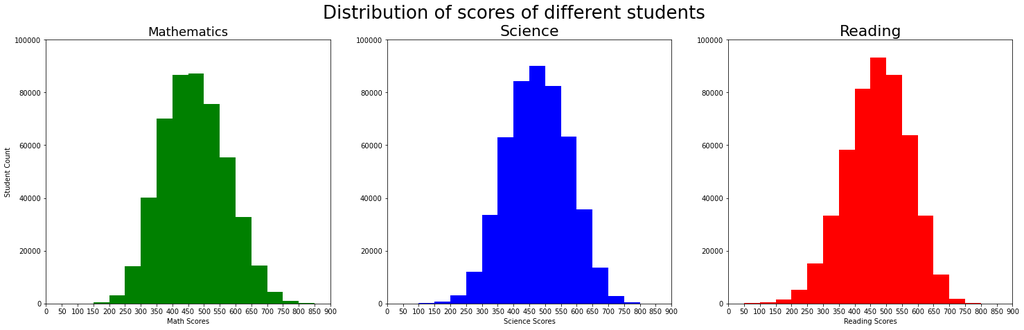

```python
plt.figure(figsize = [25, 7])

bins_hist = np.arange(0, 900 + 1, 50)

# subplot 1/3
plt.subplot(1, 3, 3)
plt.hist(pisa_2012_clean['Reading'], bins = bins_hist, color='Red');

plt.xlim(0, 900);
plt.ylim(0, 100000 + 1);
plt.xticks(bins_hist)
plt.xlabel('Reading Scores')
plt.title("Reading", fontsize=22);

# subplot 2/3
plt.subplot(1, 3, 2)
plt.hist(pisa_2012_clean['Science'], bins = bins_hist,color='Blue');

plt.xlim(0, 900);
plt.ylim(0, 100000 + 1);
plt.xticks(bins_hist)

plt.xlabel('Science Scores');
plt.title("Science", fontsize=22);


# subplot 3/3
plt.subplot(1, 3, 1)
plt.hist(pisa_2012_clean['Mathematics'], bins = bins_hist,color='Green');

plt.xlim(0, 900);
plt.ylim(0, 100000 + 1);
plt.xticks(bins_hist)
plt.xlabel('Math Scores');
plt.ylabel('Student Count')
plt.title("Mathematics", fontsize=18);


# set the overall title
plt.suptitle('Distribution of scores of different students', fontsize=26)
# save the output as png for further use
plt.savefig('univariate_barplot_totals.png')
plt.show()
```

##### Gender impact

does gender has an impact on the results?

```python
# compute the mean scores and an overall mean
df_gender_comparison = pisa_2012_clean.groupby(['Gender'])[['Mathematics','Science','Reading']].mean().reset_index()

df_gender_comparison['All'] = (df_gender_comparison['Mathematics']
                          + df_gender_comparison['Science']
                          + df_gender_comparison['Reading']) / 3
```

```python
# initiate the output dataframe
cols = ['Gender','Subject','Mean Score']
df_gender = pd.DataFrame(columns=cols)
# iterate through dataframe and set up the desired structure in new dataframe
for index, row in df_gender_comparison.iterrows():
    for columnname in ['Mathematics','Science','Reading','All']:
        df_gender = df_gender.append({'Gender': row['Gender'],
                                 'Subject': columnname,
                                 'Mean Score': row[columnname]}, ignore_index=True)
```

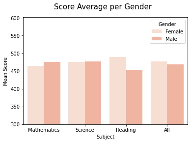

```python
sns.barplot(x="Subject",y="Mean Score",hue="Gender",data=df_gender, palette=sns.color_palette("Reds"))

# set the overall title
plt.suptitle('Score Average per Gender', fontsize=15)
plt.ylim(300,600 + 1);
# save the output as png for further use
plt.savefig('univariate_boxplot_gender.png')
plt.show()
```

there is a limited gender gap in all subjects excepts for Reading where females into reading more than males.

##### internet access impact

```python
# compute the mean scores and an overall mean
df_internet_comparison = pisa_2012_clean.groupby(['Internet Access'])[['Mathematics','Science','Reading']].mean().reset_index()
df_internet_comparison['All'] = (df_internet_comparison['Mathematics']
                          + df_internet_comparison['Science']
                          + df_internet_comparison['Reading']) / 3
```

```python
# initiate the output dataframe
cols = ['Internet Access','Subject','Mean Score']
df_internet_access = pd.DataFrame(columns=cols)
# iterate through dataframe and set up the desired structure in new dataframe
for index, row in df_internet_comparison.iterrows():
    for columnname in ['Mathematics','Science','Reading','All']:
        df_internet_access = df_internet_access.append({'Internet Access': row['Internet Access'],
                                 'Subject': columnname,
                                 'Mean Score': row[columnname]}, ignore_index=True)
```

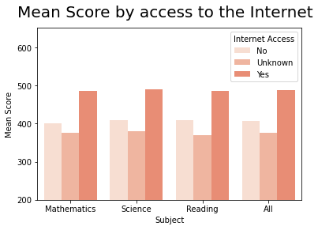

```python
# visualizing the output
sns.barplot(x="Subject",y="Mean Score",hue="Internet Access",data=df_internet_access, palette=sns.color_palette("Reds"))
# set the overall title
plt.suptitle('Mean Score by access to the Internet', fontsize=20)
plt.ylim(200, 650 + 1);
# save the output as png for further use
plt.savefig('univariate_boxplot_internetaccess.png')
plt.show()
```

this is very clear the better internet access to the students, more grades they get on their exams.

### 2. Bivariate Statistics

In the following section of the analysis we want to focus on the performances of different geographical regions. by plotting figure comparing the performance of each region for each subject as well as the overall performance.

be guided that all of the boxes need to be sorted descending.

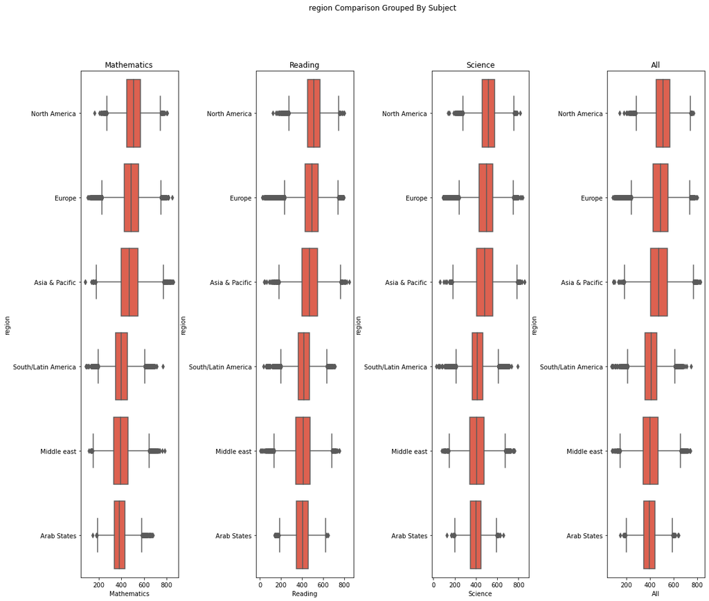

```python
# set up the figure
plt.figure(figsize = [18, 15])
plt.subplots_adjust(wspace = 0.80) # control whitespace

pisa_2012_clean['All'] = (pisa_2012_clean['Mathematics']
                          + pisa_2012_clean['Science']
                          + pisa_2012_clean['Reading']) / 3

# set the orders descending
math_order = pisa_2012_clean.groupby('region')['Mathematics'].mean().sort_values(ascending = False).index
reading_order = pisa_2012_clean.groupby('region')['Reading'].mean().sort_values(ascending = False).index
science_order = pisa_2012_clean.groupby('region')['Science'].mean().sort_values(ascending = False).index
all_order = pisa_2012_clean.groupby('region')['All'].mean().sort_values(ascending = False).index

# subplot 1/4
plt.subplot(1, 4, 1)
sns.boxplot(x = pisa_2012_clean['Mathematics'], y = pisa_2012_clean['region'],
            order = math_order, color=sns.color_palette("Reds")[3]);
plt.ylabel('region')
plt.title('Mathematics');

#subplot 2/4
plt.subplot(1, 4, 2)
sns.boxplot(x = pisa_2012_clean['Reading'], y = pisa_2012_clean['region'],
            order = reading_order, color=sns.color_palette("Reds")[3]);
plt.title('Reading');

# subplot 3/4
plt.subplot(1, 4, 3)
sns.boxplot(x = pisa_2012_clean['Science'], y = pisa_2012_clean['region'],
            order = science_order, color=sns.color_palette("Reds")[3]);
plt.title('Science');

# subplot 4/4
plt.subplot(1, 4, 4)
sns.boxplot(x = pisa_2012_clean['All'], y = pisa_2012_clean['region'],
            order = science_order, color=sns.color_palette("Reds")[3]);
plt.title('All');

# set the overall title
plt.suptitle('region Comparison Grouped By Subject');
# save the output as png for further use
plt.savefig('bivariate_boxplot_regioncomparison.png')
plt.show()
```

### 3. Multivariate

in this part we will analyze the correlations between all subjects results

our purpose is to see if there is a corr between different scores

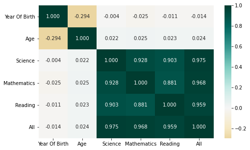

```python
# plotting the Correlation
plt.figure(figsize = [8, 5])
sns.heatmap(pisa_2012_clean.corr(), annot = True, fmt = '.3f',
           cmap = 'BrBG', center = 0)
plt.show()
```

## Conclusion

- We have found that the scores in each of the subjects seem to be normally distributed. The major part of the students gets a score between 300 and 600. There is no difference to see between the subjects (median values not significantly different).
- countries out of 10 in the top-10 country list are in Asia. The other 3 countries are European countries. China-Shanghai is in the top spot for all of the subjects and therefore also tops the overall rankings. The opposite is the case for Peru that ranks last in all of the categories.
- there is a limited gender gap in all subjects excepts for Reading where females into reading more than males.however, Male students seem to be slightly better in Mathematics though while for the subject Science it seems to be very balanced. The overall performance of female students still seems to be better than the one from male students._
- this is very clear the better internet access to the students, more grades they get on their exams.